# CPUE Data Analysis

Based upon conversations with Pravin from Stats, use log10 CPUE rather than standardise by estuary/species

Load data and clean up and standardise the winds

```r
library(ggplot2)
library(DHARMa)
library(bootpredictlme4)
library(merTools)
library(effects)
library(MuMIn)
library(dplyr)
library(ggeffects)
library(glmmTMB)
library(tweedie)
# Use Log10(CPUE) rather than standardise


# Load Data
mydata <- read.csv("../Data/Full_Data_Modelling_BARRA_by_estuary.csv", header = T) # Full_Data_ModellingV3_by_estuary.csv
# mydata2 <-  read.csv("Full_Data_Modelling.csv", header = T)
#
# cor.test(mydata$X45_degree_winds, mydata2$X135_degree_winds)
# cor.test(mydata$X135_degree_winds, mydata2$X45_degree_winds)
# cor.test(mydata$X135_degree_winds, mydata2$X135_degree_winds)
# cor.test(mydata$X45_degree_winds, mydata2$X45_degree_winds)
# # NE winds not correlated by SE winds are.....

# Remove Total CPUE
mydata <- subset(mydata, Species != "Total")

### Standardise Winds
my.df <-  mydata %>% group_by(Species, Estuary) %>% mutate(X45_degree_winds.standardised = as.numeric(scale(X45_degree_winds)),
                           X135_degree_winds.standardised = as.numeric(scale(X135_degree_winds)))
```

Investigate the environmental variation over time and the stability of the CPUE over time

```r
head(my.df)
```

| Year | CPUE | Species | Estuary | Estuary_Type | X45_degree_winds | X135_degree_winds | Drought_declared_1m | Drought_declared_6m | Drought_Months | Modal_Age | Spawning_Period | Catch | Effort_days | X45_degree_winds.standardised | X135_degree_winds.standardised |
| --- | --- | --- | --- | --- | --- | --- | --- | --- | --- | --- | --- | --- | --- | --- | --- |
| 1997 | 5.597157 | Bream | Camden River | Barrier River | 9994.509 | 18851.30 | Drought | No Drought | 2 | 7 | Oct-Feb | 875.9 | 148 | -0.76989213 | -0.53609286 |
| 1998 | 6.254047 | Bream | Camden River | Barrier River | 19603.421 | 10395.83 | No Drought | No Drought | 0 | 7 | Oct-Feb | 1037.0 | 166 | 0.59934198 | -1.10863038 |
| 1999 | 4.689744 | Bream | Camden River | Barrier River | 16838.525 | 47951.59 | No Drought | No Drought | 0 | 7 | Oct-Feb | 872.1 | 187 | 0.20535465 | 1.43434886 |
| 2000 | 3.711016 | Bream | Camden River | Barrier River | 15562.659 | 18534.25 | No Drought | No Drought | 0 | 7 | Oct-Feb | 835.8 | 172 | 0.02354852 | -0.55756093 |
| 2001 | 8.869224 | Bream | Camden River | Barrier River | 24531.577 | 25886.31 | No Drought | No Drought | 0 | 7 | Oct-Feb | 1276.5 | 150 | 1.30158575 | -0.05973732 |
| 2002 | 12.244613 | Bream | Camden River | Barrier River | 17726.597 | 33310.35 | Drought | Drought | 8 | 7 | Oct-Feb | 1571.5 | 124 | 0.33190153 | 0.44295996 |

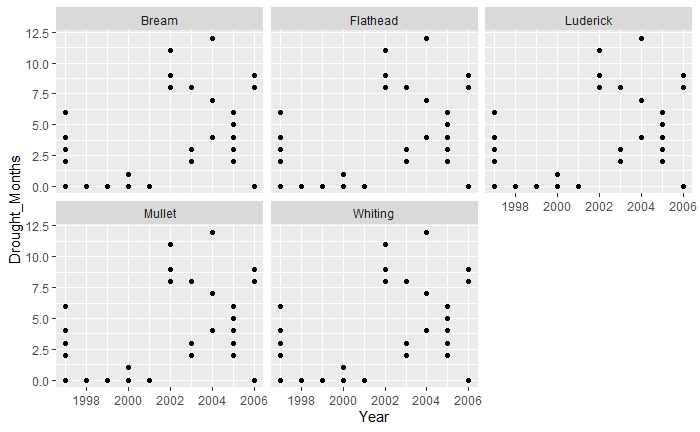

```r
ggplot(my.df, aes(x=Year, y = Drought_Months)) + geom_point() + facet_wrap(~Species)
```

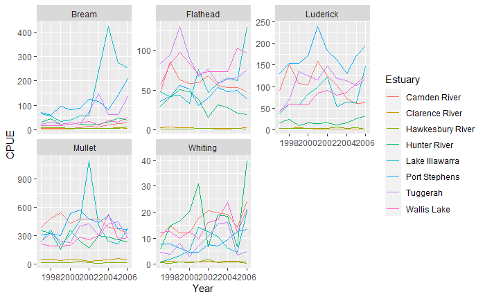

```r
ggplot(my.df, aes(x=Year, y = CPUE, col= Estuary)) + geom_line() + facet_wrap(~Species, scales = "free_y")
```

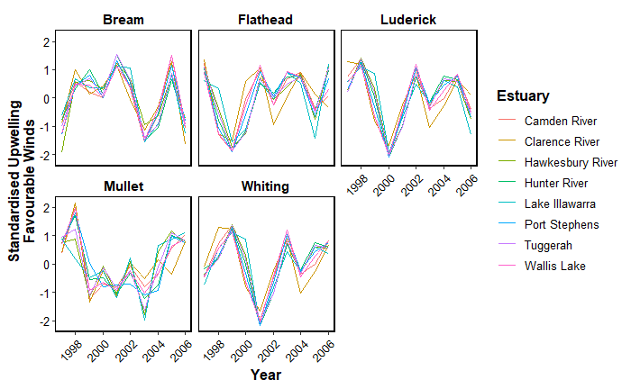

```r
# the next two suggest my scaling of the winds was not good enough.
ggplot(my.df, aes(x=Year, y = X45_degree_winds.standardised, col= Estuary)) + geom_line() + facet_wrap(~Species) +
  theme_classic() + ylab("Standardised Upwelling\nFavourable Winds") +
  theme(axis.title = element_text(face="bold", size=12),
        axis.text.x = element_text(colour = "black", size = 10, angle=45, hjust = 1),
        axis.text.y = element_text(colour = "black", size = 10),
        strip.text = element_text(colour="black", face = "bold", size = 11, hjust=0.5),
        strip.background = element_blank(),
        panel.border = element_rect(colour = "black", fill=NA, size = 1),
        legend.title = element_text(colour="black", size = 12, face = "bold"),
        legend.text = element_text(colour="black", size=10))

ggsave("../plots/Upwelling Winds by species_time_estuary.png", height = 14.8, width=21, dpi =600)
```

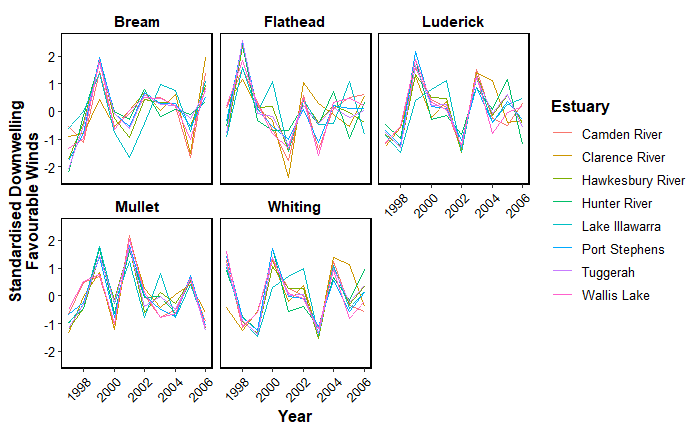

```r
ggplot(my.df, aes(x=Year, y = X135_degree_winds.standardised, col= Estuary)) + geom_line() + facet_wrap(~Species)+
  theme_classic() + ylab("Standardised Downwelling\nFavourable Winds") +
  theme(axis.title = element_text(face="bold", size=12),
        axis.text.x = element_text(colour = "black", size = 10, angle=45, hjust = 1),
        axis.text.y = element_text(colour = "black", size = 10),
        strip.text = element_text(colour="black", face = "bold", size = 11, hjust=0.5),
        strip.background = element_blank(),
        panel.border = element_rect(colour = "black", fill=NA, size = 1),
        legend.title = element_text(colour="black", size = 12, face = "bold"),
        legend.text = element_text(colour="black", size=10))#, scales = "free_y")
ggsave("../plots/Downwelling Winds by species_time_estuary.png", height = 14.8, width=21, dpi =600)
```

```r
NA
NA
```

Do full model for all species

```r
m7 <- glmmTMB(Catch ~ poly(X135_degree_winds.standardised, degree = 2) +
       poly(X45_degree_winds.standardised, degree = 2) +
       X135_degree_winds.standardised:X45_degree_winds.standardised+
        Estuary_Type *Drought_Months + Species + (Species|Estuary), family = Gamma(link="log"),
       data = my.df, offset = log10(Effort_days))
```

```
Model convergence problem; non-positive-definite Hessian matrix. See vignette('troubleshooting')Model convergence problem; singular convergence (7). See vignette('troubleshooting')
```

```r
AIC(m7) # -38.18
```

```
[1] NA
```

```r
performance::r2(m7) # 0.08
```

```
# R2 for Mixed Models

  Conditional R2: 0.954
     Marginal R2: 0.523
```

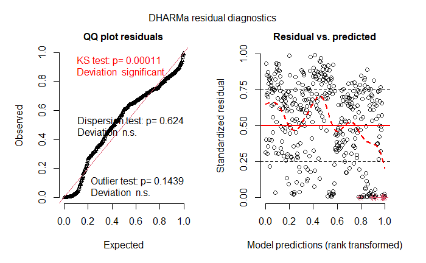

```r
simulationOutput <- simulateResiduals(fittedModel = m7, n = 250)
plot(simulationOutput, quantreg = F)
```

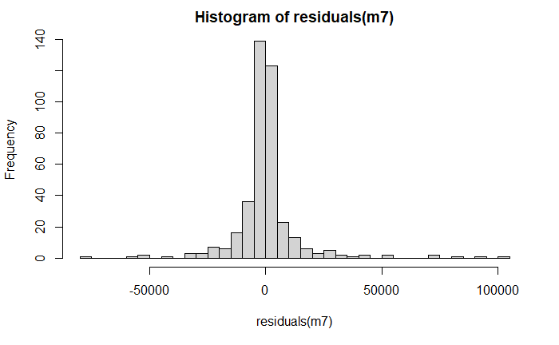

```r
hist(residuals(m7), breaks = 30)
```

```r
car::Anova(m7)
```

```
Analysis of Deviance Table (Type II Wald chisquare tests)

Response: Catch
                                                                Chisq Df Pr(>Chisq)
poly(X135_degree_winds.standardised, degree = 2)               0.1240  2  0.9398858
poly(X45_degree_winds.standardised, degree = 2)               17.0592  2  0.0001975 ***
Estuary_Type                                                  10.3486  2  0.0056601 **
Drought_Months                                                11.5827  1  0.0006657 ***
Species                                                      676.1579  4  < 2.2e-16 ***
X135_degree_winds.standardised:X45_degree_winds.standardised   7.6313  1  0.0057365 **
Estuary_Type:Drought_Months                                   17.6915  2  0.0001440 ***
---
Signif. codes:  0 ‘***’ 0.001 ‘**’ 0.01 ‘*’ 0.05 ‘.’ 0.1 ‘ ’ 1
```

```r
summary(m7)
```

```
 Family: Gamma  ( log )
Formula:          Catch ~ poly(X135_degree_winds.standardised, degree = 2) + poly(X45_degree_winds.standardised,
    degree = 2) + X135_degree_winds.standardised:X45_degree_winds.standardised +      Estuary_Type * Drought_Months + Species + (Species | Estuary)
Data: my.df
 Offset: log10(Effort_days)

     AIC      BIC   logLik deviance df.resid
      NA       NA       NA       NA      369

Random effects:

Conditional model:
 Groups  Name            Variance Std.Dev. Corr
 Estuary (Intercept)     0.7785   0.8823
         SpeciesFlathead 1.1928   1.0921    0.07
         SpeciesLuderick 0.9067   0.9522   -0.11  0.86
         SpeciesMullet   0.6523   0.8076   -0.33  0.81  0.72
         SpeciesWhiting  1.0612   1.0302   -0.49  0.76  0.60  0.92
Number of obs: 400, groups:  Estuary, 8

Dispersion estimate for Gamma family (sigma^2): 0.135

Conditional model:
                                                             Estimate Std. Error z value Pr(>|z|)
(Intercept)                                                   6.22097    0.37387  16.639  < 2e-16 ***
poly(X135_degree_winds.standardised, degree = 2)1             0.09107    0.41150   0.221  0.82485
poly(X135_degree_winds.standardised, degree = 2)2             0.11851    0.42385   0.280  0.77979
poly(X45_degree_winds.standardised, degree = 2)1             -1.50109    0.40492  -3.707  0.00021 ***
poly(X45_degree_winds.standardised, degree = 2)2              0.69846    0.40547   1.723  0.08496 .
Estuary_TypeBarrier River                                     0.16145    0.32690   0.494  0.62139
Estuary_TypeDrowned River Valley                              1.33621    0.44396   3.010  0.00261 **
Drought_Months                                                0.05019    0.00970   5.174 2.29e-07 ***
SpeciesFlathead                                              -0.11450    0.39058  -0.293  0.76939
SpeciesLuderick                                               0.26137    0.34175   0.765  0.44439
SpeciesMullet                                                 1.96149    0.29147   6.730 1.70e-11 ***
SpeciesWhiting                                               -1.50981    0.36893  -4.092 4.27e-05 ***
X135_degree_winds.standardised:X45_degree_winds.standardised -0.07893    0.02857  -2.762  0.00574 **
Estuary_TypeBarrier River:Drought_Months                     -0.05258    0.01250  -4.206 2.60e-05 ***
Estuary_TypeDrowned River Valley:Drought_Months              -0.02985    0.01473  -2.026  0.04272 *
---
Signif. codes:  0 ‘***’ 0.001 ‘**’ 0.01 ‘*’ 0.05 ‘.’ 0.1 ‘ ’ 1
```

```r
total_Summary <- broom.mixed::tidy(m7)
total_Summary
```

| effect | component | group | term | estimate | std.error | statistic | p.value |
| --- | --- | --- | --- | --- | --- | --- | --- |
| fixed | cond | NA | (Intercept) | 6.22096951 | 0.373871757 | 16.6393139 | 3.617393e-62 |
| fixed | cond | NA | poly(X135_degree_winds.standardised, degree = 2)1 | 0.09106813 | 0.411500052 | 0.2213077 | 8.248529e-01 |
| fixed | cond | NA | poly(X135_degree_winds.standardised, degree = 2)2 | 0.11850640 | 0.423852186 | 0.2795937 | 7.797892e-01 |
| fixed | cond | NA | poly(X45_degree_winds.standardised, degree = 2)1 | -1.50109397 | 0.404916962 | -3.7071650 | 2.095924e-04 |
| fixed | cond | NA | poly(X45_degree_winds.standardised, degree = 2)2 | 0.69846031 | 0.405464881 | 1.7226160 | 8.495798e-02 |
| fixed | cond | NA | Estuary_TypeBarrier River | 0.16144823 | 0.326896802 | 0.4938813 | 6.213900e-01 |
| fixed | cond | NA | Estuary_TypeDrowned River Valley | 1.33620464 | 0.443956493 | 3.0097648 | 2.614500e-03 |
| fixed | cond | NA | Drought_Months | 0.05018969 | 0.009699647 | 5.1743832 | 2.286651e-07 |
| fixed | cond | NA | SpeciesFlathead | -0.11450460 | 0.390577238 | -0.2931676 | 7.693940e-01 |
| fixed | cond | NA | SpeciesLuderick | 0.26136568 | 0.341746416 | 0.7647942 | 4.443941e-01 |

[output cut: 20 more lines]

```r
write.csv(total_Summary, "../Data/All Species Summary Table.csv", row.names = F)
```

Save model checking plots - These were combined manually in Inkscape later

```r
png("../plots/Model checks/Mulitspecies model 1.png", width = 21, height = 14.8, units = "cm", res = 600)
plot(simulationOutput, quantreg = F)
dev.off()
```

```r
png("../plots/Model checks/Mulitspecies model 2.png", width = 21, height = 14.8, units = "cm", res = 600)
```

```r
hist(residuals(m7), breaks = 30)
dev.off()
```

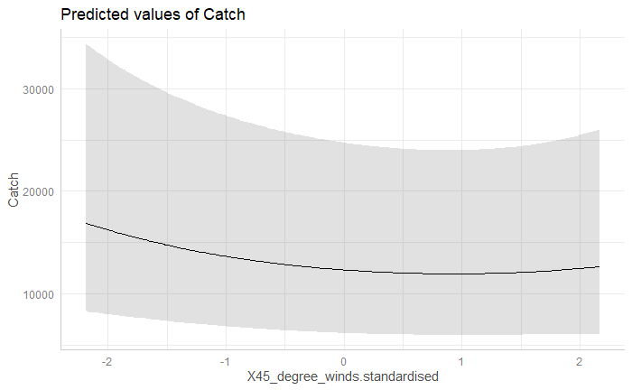

```r
plot(ggeffect(m7, terms = "X45_degree_winds.standardised [all]"))
```

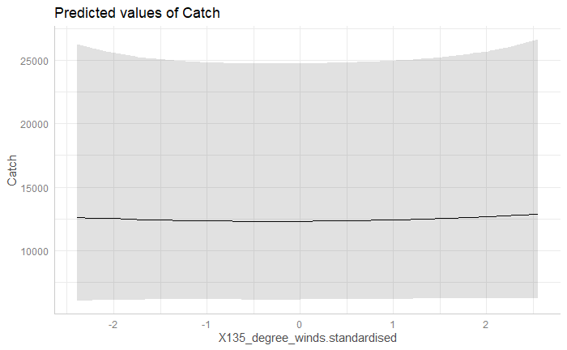

```r
plot(ggeffect(m7, terms = "X135_degree_winds.standardised [all]"))
```

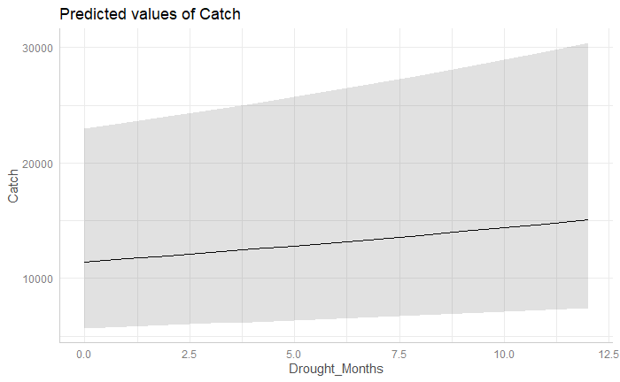

```r
plot(ggeffect(m7, terms = "Drought_Months [all]"))
```

Heatmap making for interaction plot (Run from here) - Very slow if standard error included (was run on HPC to get SE)

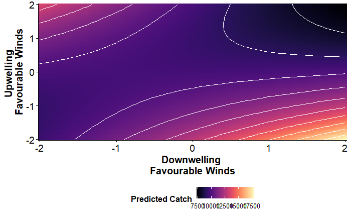

```r
nums <- seq(-2,2, by = 0.05)
heat_dataM <- data.frame("X135_degree_winds.standardised" = rep(0,81*81), # makes empty dataframe ready for values
                         "X45_degree_winds.standardised" =  rep(0,81*81),
                         "Catch" =  rep(0,81*81))
Nn <- 1
# loop for NE
for (i in 1:length(nums)){
  for (j in 1:length(nums)){
    pred_map <- data.frame("X45_degree_winds.standardised" = nums[i],
                           "X135_degree_winds.standardised" = nums[j],
                           "Drought_Months" = mean(my.df$Drought_Months),
                           "Estuary_Type" = "Drowned River Valley",
                           "Estuary" = "Hawkesbury River",
                           "Species" = "Bream",
                           "Effort_days" = mean(my.df$Effort_days))
    PredX <- predict(m7, newdata = pred_map, type = "response", se.fit = F)
    heat_dataM$Southeast.Winds[Nn] <- pred_map$X135_degree_winds.standardised[1]
    heat_dataM$Northeast.Winds[Nn] <- pred_map$X45_degree_winds.standardised[1]
    heat_dataM$Abundance[Nn] <- PredX#$fit
    #print(paste("This is line ", Nn, " out of 6561"))
    Nn <- Nn + 1
  }
}

pH <- ggplot(heat_dataM, aes(x = Southeast.Winds,y = Northeast.Winds)) + geom_tile(aes(fill = Abundance)) +
  geom_contour(col="white", aes(z = Abundance)) +#, binwidth = 0.002
  scale_x_continuous(expand = c(0,0)) +
  scale_y_continuous(expand = c(0,0)) +
  #scale_fill_gradient(low = "blue", high = "red") +
  theme_classic() +
  viridis::scale_fill_viridis(option = "magma", name="Predicted Catch") + # or geom_raster()
  xlab("Downwelling \nFavourable Winds") + ylab("Upwelling \nFavourable Winds") +
  theme(axis.title.x = element_text(face="bold", colour="black", size = 15),
        axis.text.x  = element_text(colour="black", size = 14),
        axis.title.y = element_text(face="bold", colour="black", size = 15),
        axis.text.y  = element_text(colour="black", size = 14),
        axis.ticks = element_line(colour="black"),
        legend.title = element_text(colour="black", size=12, face="bold"),
        legend.text = element_text(colour="black", size=10),
        legend.position = "bottom")

pH
```

```r
write.csv(heat_dataM, "../Data/All Species heamap prediction data.csv", row.names = F)
```

Now for some species specific Models Bream First Prepare Data

```r
bream <- subset(my.df, Species == "Bream")
```

Model

```r
m1 <- glmmTMB(Catch ~ poly(X135_degree_winds.standardised, degree = 2) +
       poly(X45_degree_winds.standardised, degree = 2) +
       X135_degree_winds.standardised:X45_degree_winds.standardised+
        Estuary_Type *Drought_Months + (1|Estuary) , family = Gamma(link="log"),
       data = bream, offset = log10(Effort_days))
performance::r2(m1)
```

```
# R2 for Mixed Models

  Conditional R2: 0.813
     Marginal R2: 0.467
```

```r
AIC(m1) # 43.17
```

```
[1] 1623.72
```

Check assumptions

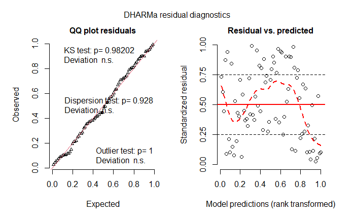

```r
simulationOutput <- simulateResiduals(fittedModel = m1, n = 250)
plot(simulationOutput, quantreg = F)
```

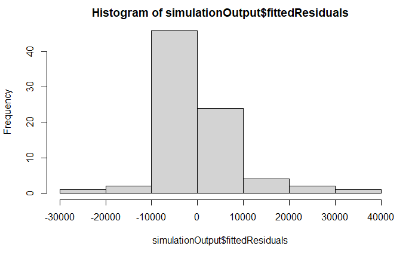

```r
# histograms
hist(simulationOutput$fittedResiduals)
```

Model checking plots - note these were combined in Inkscape manually later

```r
png("../plots/Model checks/Bream model 1.png", width = 21, height = 14.8, units = "cm", res = 600)
plot(simulationOutput, quantreg = F)
dev.off()
```

```r
png("../plots/Model checks/Bream model 2.png", width = 21, height = 14.8, units = "cm", res = 600)
```

```r
hist(residuals(m1))
dev.off()
```

Check significance

```r
car::Anova(m1)
```

```
Analysis of Deviance Table (Type II Wald chisquare tests)

Response: Catch
                                                               Chisq Df Pr(>Chisq)
poly(X135_degree_winds.standardised, degree = 2)              0.7728  2  0.6794892
poly(X45_degree_winds.standardised, degree = 2)               3.4089  2  0.1818703
Estuary_Type                                                  8.0436  2  0.0179207 *
Drought_Months                                               13.6700  1  0.0002179 ***
X135_degree_winds.standardised:X45_degree_winds.standardised  5.5888  1  0.0180753 *
Estuary_Type:Drought_Months                                   3.8132  2  0.1485865
---
Signif. codes:  0 ‘***’ 0.001 ‘**’ 0.01 ‘*’ 0.05 ‘.’ 0.1 ‘ ’ 1
```

```r
summary(m1)
```

```
 Family: Gamma  ( log )
Formula:          Catch ~ poly(X135_degree_winds.standardised, degree = 2) + poly(X45_degree_winds.standardised,
    degree = 2) + X135_degree_winds.standardised:X45_degree_winds.standardised +      Estuary_Type * Drought_Months + (1 | Estuary)
Data: bream
 Offset: log10(Effort_days)

     AIC      BIC   logLik deviance df.resid
  1623.7   1654.7   -798.9   1597.7       67

Random effects:

Conditional model:
 Groups  Name        Variance Std.Dev.
 Estuary (Intercept) 0.3368   0.5803
Number of obs: 80, groups:  Estuary, 8

Dispersion estimate for Gamma family (sigma^2): 0.182

Conditional model:
                                                             Estimate Std. Error z value Pr(>|z|)
(Intercept)                                                   6.87213    0.35501  19.358  < 2e-16 ***
poly(X135_degree_winds.standardised, degree = 2)1             0.31913    0.45812   0.697 0.486040
poly(X135_degree_winds.standardised, degree = 2)2             0.22490    0.47575   0.473 0.636404
poly(X45_degree_winds.standardised, degree = 2)1             -0.62122    0.47438  -1.310 0.190351
poly(X45_degree_winds.standardised, degree = 2)2              0.54943    0.49518   1.110 0.267189
Estuary_TypeBarrier River                                    -1.12722    0.49904  -2.259 0.023896 *
Estuary_TypeDrowned River Valley                              0.06734    0.55925   0.120 0.904154
Drought_Months                                                0.09998    0.02721   3.674 0.000239 ***
X135_degree_winds.standardised:X45_degree_winds.standardised -0.14152    0.05986  -2.364 0.018075 *
Estuary_TypeBarrier River:Drought_Months                     -0.05162    0.03412  -1.513 0.130375
Estuary_TypeDrowned River Valley:Drought_Months              -0.07157    0.03899  -1.836 0.066379 .
---
Signif. codes:  0 ‘***’ 0.001 ‘**’ 0.01 ‘*’ 0.05 ‘.’ 0.1 ‘ ’ 1
```

```r
bream_Summary <- broom.mixed::tidy(m1)
bream_Summary
```

| effect | component | group | term | estimate | std.error | statistic | p.value |
| --- | --- | --- | --- | --- | --- | --- | --- |
| fixed | cond | NA | (Intercept) | 6.87212618 | 0.35501038 | 19.3575358 | 1.761106e-83 |
| fixed | cond | NA | poly(X135_degree_winds.standardised, degree = 2)1 | 0.31913368 | 0.45811666 | 0.6966210 | 4.860400e-01 |
| fixed | cond | NA | poly(X135_degree_winds.standardised, degree = 2)2 | 0.22490387 | 0.47575357 | 0.4727319 | 6.364045e-01 |
| fixed | cond | NA | poly(X45_degree_winds.standardised, degree = 2)1 | -0.62121904 | 0.47437895 | -1.3095417 | 1.903509e-01 |
| fixed | cond | NA | poly(X45_degree_winds.standardised, degree = 2)2 | 0.54942950 | 0.49517843 | 1.1095586 | 2.671893e-01 |
| fixed | cond | NA | Estuary_TypeBarrier River | -1.12722090 | 0.49903713 | -2.2587917 | 2.389635e-02 |
| fixed | cond | NA | Estuary_TypeDrowned River Valley | 0.06734285 | 0.55925430 | 0.1204154 | 9.041541e-01 |
| fixed | cond | NA | Drought_Months | 0.09997771 | 0.02721295 | 3.6739016 | 2.388747e-04 |
| fixed | cond | NA | X135_degree_winds.standardised:X45_degree_winds.standardised | -0.14151782 | 0.05986191 | -2.3640713 | 1.807533e-02 |
| fixed | cond | NA | Estuary_TypeBarrier River:Drought_Months | -0.05161713 | 0.03412425 | -1.5126229 | 1.303755e-01 |

[output cut: 2 more lines]

```r
write.csv(bream_Summary, "../Data/Bream Summary Table.csv", row.names = F)
```

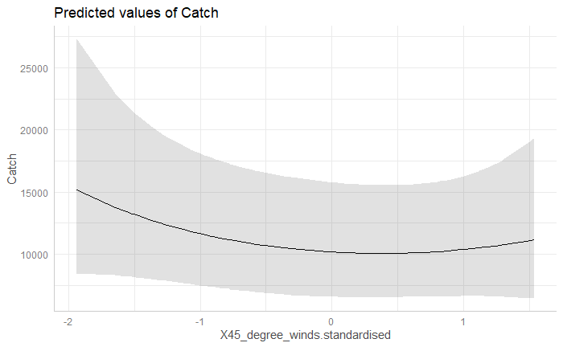

```r
plot(ggeffect(m1, terms = "X45_degree_winds.standardised [all]"))
```

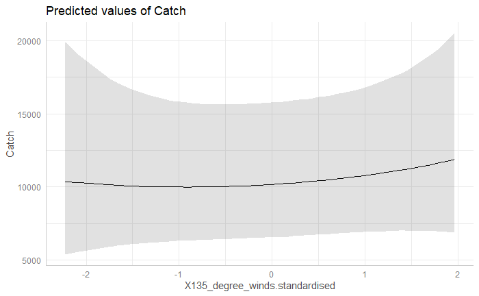

```r
plot(ggeffect(m1, terms = "X135_degree_winds.standardised [all]"))
```

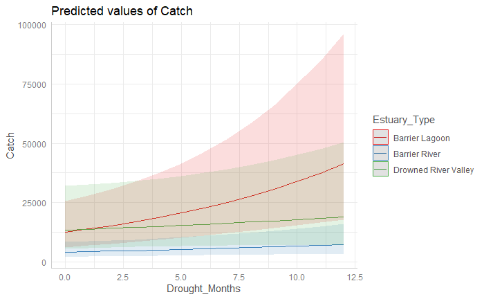

```r
plot(ggeffect(m1, terms = c("Drought_Months", "Estuary_Type")))
```

Heatmap making for interaction plot (Run from here) - Very slow if standard error included (was run on HPC to get SE)

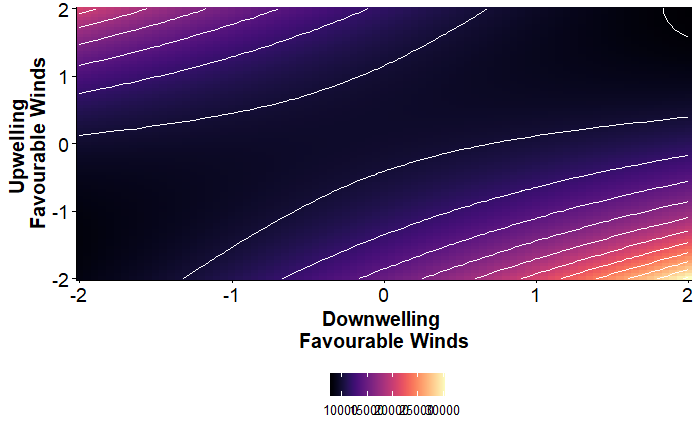

```r
nums <- seq(-2,2, by = 0.05)
heat_dataBream <- data.frame("X135_degree_winds.standardised" = rep(0,81*81), # makes empty dataframe ready for values
                         "X45_degree_winds.standardised" =  rep(0,81*81),
                         "Catch" =  rep(0,81*81))
Nn <- 1
# loop for NE
for (i in 1:length(nums)){
  for (j in 1:length(nums)){
    pred_map <- data.frame("X45_degree_winds.standardised" = nums[i],
                           "X135_degree_winds.standardised" = nums[j],
                           "Drought_Months" = mean(my.df$Drought_Months),
                           "Estuary_Type" = "Drowned River Valley",
                           "Estuary" = "Hawkesbury River",
                           "Effort_days" = mean(my.df$Effort_days))
    PredX <- predict(m1, newdata = pred_map, type = "response", se.fit = F)
    heat_dataBream$Southeast.Winds[Nn] <- pred_map$X135_degree_winds.standardised[1]
    heat_dataBream$Northeast.Winds[Nn] <- pred_map$X45_degree_winds.standardised[1]
    heat_dataBream$Abundance[Nn] <- PredX#$fit
    #print(paste("This is line ", Nn, " out of 6561"))
    Nn <- Nn + 1
  }
}

pB <- ggplot(heat_dataBream, aes(x = Southeast.Winds,y = Northeast.Winds)) + geom_tile(aes(fill = Abundance)) +
  geom_contour(col="white", aes(z = Abundance)) +#, binwidth = 0.002
  scale_x_continuous(expand = c(0,0)) +
  scale_y_continuous(expand = c(0,0)) +
  #scale_fill_gradient(low = "blue", high = "red") +
  theme_classic() +
  viridis::scale_fill_viridis(option = "magma", name="Predicted Catch") + # or geom_raster()
  xlab("Downwelling \nFavourable Winds") + ylab("Upwelling \nFavourable Winds") +
  theme(axis.title.x = element_text(face="bold", colour="black", size = 15),
        axis.text.x  = element_text(colour="black", size = 14),
        axis.title.y = element_text(face="bold", colour="black", size = 15),
        axis.text.y  = element_text(colour="black", size = 14),
        axis.ticks = element_line(colour="black"),
        legend.title = element_blank(),
        legend.text = element_text(colour="black", size=10),
        legend.position = "bottom")

pB
```

```r
 write.csv(heat_dataBream, "../Data/Bream heamap prediction data.csv", row.names = F)
```

##Now Mullet## Prepare Data

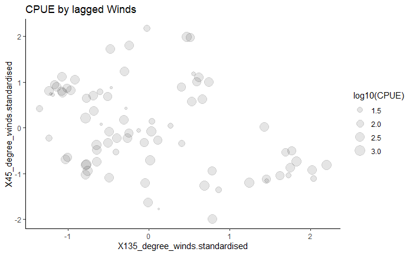

```r
mullet <- subset(my.df, Species == "Mullet")

p2 <- ggplot(mullet, aes(x = X135_degree_winds.standardised,y = X45_degree_winds.standardised, size = log10(CPUE))) + geom_point(alpha = 0.1) +
  theme_classic() + labs(title = "CPUE by lagged Winds")
p2
```

Model

```r
m2 <- glmmTMB(Catch ~ poly(X135_degree_winds.standardised, degree = 2) +
       poly(X45_degree_winds.standardised, degree = 2) +
       X135_degree_winds.standardised:X45_degree_winds.standardised+
        Estuary_Type *Drought_Months + (1|Estuary) , family = Gamma(link="log"),
       data = mullet, offset = log10(Effort_days))
performance::r2(m2) # 0.147
```

```
# R2 for Mixed Models

  Conditional R2: 0.856
     Marginal R2: 0.184
```

```r
AIC(m2) # -22.726
```

```
[1] 1878.339
```

Check assumptions

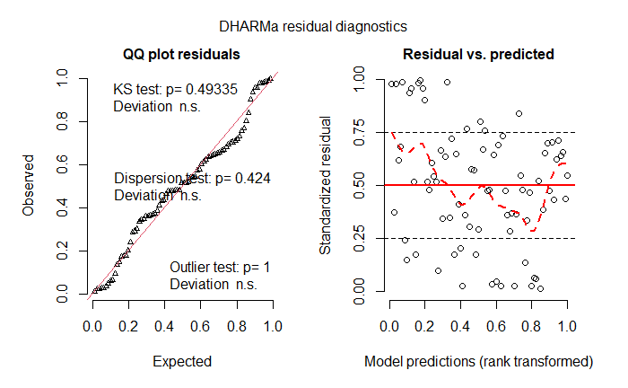

```r
simulationOutput <- simulateResiduals(fittedModel = m2, n = 250)
plot(simulationOutput, quantreg =F)
```

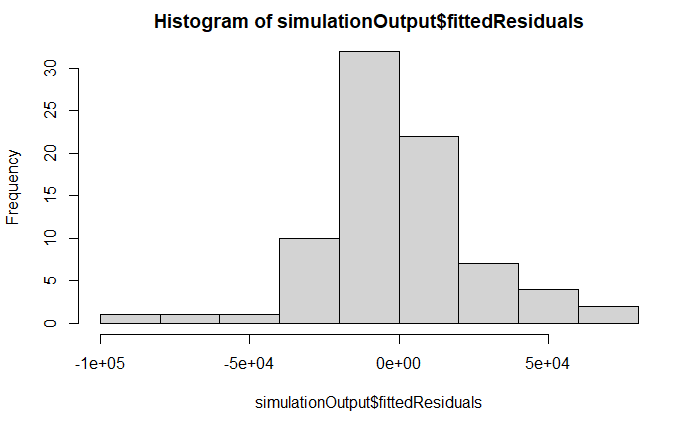

```r
# histograms
hist(simulationOutput$fittedResiduals)
```

```r
png("../plots/Model checks/Mullet model 1.png", width = 21, height = 14.8, units = "cm", res = 600)
plot(simulationOutput, quantreg = F)
dev.off()
```

```r
png("../plots/Model checks/Mullet model 2.png", width = 21, height = 14.8, units = "cm", res = 600)
```

```r
hist(residuals(m2))
dev.off()
```

Check significance

```r
car::Anova(m2)
```

```
Analysis of Deviance Table (Type II Wald chisquare tests)

Response: Catch
                                                               Chisq Df Pr(>Chisq)
poly(X135_degree_winds.standardised, degree = 2)              0.3589  2   0.835729
poly(X45_degree_winds.standardised, degree = 2)               3.1194  2   0.210201
Estuary_Type                                                  1.7870  2   0.409222
Drought_Months                                                0.4611  1   0.497116
X135_degree_winds.standardised:X45_degree_winds.standardised  0.6575  1   0.417454
Estuary_Type:Drought_Months                                  12.7925  2   0.001668 **
---
Signif. codes:  0 ‘***’ 0.001 ‘**’ 0.01 ‘*’ 0.05 ‘.’ 0.1 ‘ ’ 1
```

```r
summary(m2)
```

```
 Family: Gamma  ( log )
Formula:          Catch ~ poly(X135_degree_winds.standardised, degree = 2) + poly(X45_degree_winds.standardised,
    degree = 2) + X135_degree_winds.standardised:X45_degree_winds.standardised +      Estuary_Type * Drought_Months + (1 | Estuary)
Data: mullet
 Offset: log10(Effort_days)

     AIC      BIC   logLik deviance df.resid
  1878.3   1909.3   -926.2   1852.3       67

Random effects:

Conditional model:
 Groups  Name        Variance Std.Dev.
 Estuary (Intercept) 0.3302   0.5746
Number of obs: 80, groups:  Estuary, 8

Dispersion estimate for Gamma family (sigma^2): 0.0708

Conditional model:
                                                             Estimate Std. Error z value Pr(>|z|)
(Intercept)                                                   8.81347    0.34008  25.916  < 2e-16 ***
poly(X135_degree_winds.standardised, degree = 2)1            -0.12559    0.36622  -0.343  0.73164
poly(X135_degree_winds.standardised, degree = 2)2             0.14625    0.40408   0.362  0.71740
poly(X45_degree_winds.standardised, degree = 2)1             -0.52316    0.29676  -1.763  0.07792 .
poly(X45_degree_winds.standardised, degree = 2)2              0.06995    0.32647   0.214  0.83034
Estuary_TypeBarrier River                                     0.01418    0.47939   0.030  0.97640
Estuary_TypeDrowned River Valley                             -0.48044    0.53546  -0.897  0.36958
Drought_Months                                                0.03698    0.01608   2.300  0.02144 *
X135_degree_winds.standardised:X45_degree_winds.standardised  0.05073    0.06257   0.811  0.41745
Estuary_TypeBarrier River:Drought_Months                     -0.06664    0.02087  -3.193  0.00141 **
Estuary_TypeDrowned River Valley:Drought_Months              -0.06811    0.02334  -2.918  0.00352 **
---
Signif. codes:  0 ‘***’ 0.001 ‘**’ 0.01 ‘*’ 0.05 ‘.’ 0.1 ‘ ’ 1
```

```r
mullet_Summary <- broom.mixed::tidy(m2)
mullet_Summary
```

| effect | component | group | term | estimate | std.error | statistic | p.value |
| --- | --- | --- | --- | --- | --- | --- | --- |
| fixed | cond | NA | (Intercept) | 8.81346611 | 0.34008172 | 25.91573046 | 4.427903e-148 |
| fixed | cond | NA | poly(X135_degree_winds.standardised, degree = 2)1 | -0.12559442 | 0.36622411 | -0.34294417 | 7.316405e-01 |
| fixed | cond | NA | poly(X135_degree_winds.standardised, degree = 2)2 | 0.14624684 | 0.40407512 | 0.36192982 | 7.174045e-01 |
| fixed | cond | NA | poly(X45_degree_winds.standardised, degree = 2)1 | -0.52315940 | 0.29676160 | -1.76289451 | 7.791828e-02 |
| fixed | cond | NA | poly(X45_degree_winds.standardised, degree = 2)2 | 0.06995159 | 0.32647049 | 0.21426620 | 8.303395e-01 |
| fixed | cond | NA | Estuary_TypeBarrier River | 0.01417862 | 0.47938770 | 0.02957653 | 9.764048e-01 |
| fixed | cond | NA | Estuary_TypeDrowned River Valley | -0.48044326 | 0.53546053 | -0.89725241 | 3.695842e-01 |
| fixed | cond | NA | Drought_Months | 0.03698337 | 0.01607874 | 2.30014098 | 2.144023e-02 |
| fixed | cond | NA | X135_degree_winds.standardised:X45_degree_winds.standardised | 0.05073207 | 0.06256686 | 0.81084569 | 4.174543e-01 |
| fixed | cond | NA | Estuary_TypeBarrier River:Drought_Months | -0.06663851 | 0.02087335 | -3.19251592 | 1.410392e-03 |

[output cut: 2 more lines]

```r
write.csv(mullet_Summary, "../Data/Mullet Summary Table.csv", row.names = F)
```

Therefore wind is not important for mullet?

[figure not shown]

```r
plot(allEffects(m2))
```

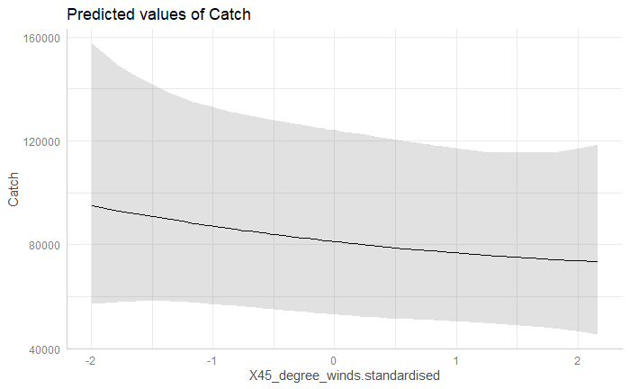

```r
plot(ggeffect(m2, terms = "X45_degree_winds.standardised [all]"))
```

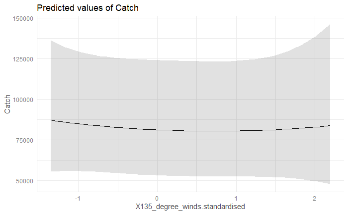

```r
plot(ggeffect(m2, terms = "X135_degree_winds.standardised [all]"))
```

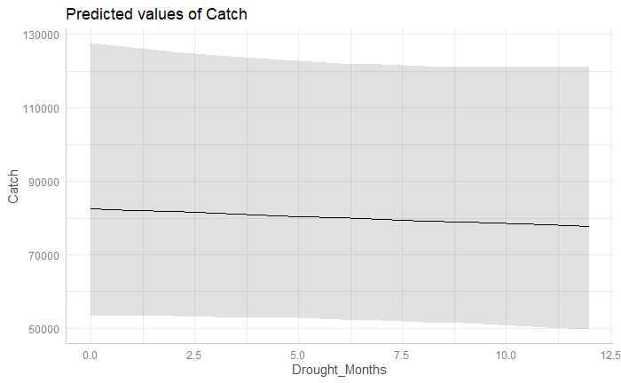

```r
plot(ggeffect(m2, terms = "Drought_Months [all]"))
```

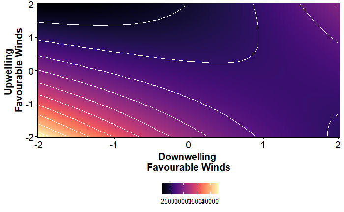

```r
nums <- seq(-2,2, by = 0.05)
heat_dataMullet <- data.frame("X135_degree_winds.standardised" = rep(0,81*81), # makes empty dataframe ready for values
                         "X45_degree_winds.standardised" =  rep(0,81*81),
                         "Catch" =  rep(0,81*81))
Nn <- 1
# loop for NE
for (i in 1:length(nums)){
  for (j in 1:length(nums)){
    pred_map <- data.frame("X45_degree_winds.standardised" = nums[i],
                           "X135_degree_winds.standardised" = nums[j],
                           "Drought_Months" = mean(my.df$Drought_Months),
                           "Estuary_Type" = "Drowned River Valley",
                           "Estuary" = "Hawkesbury River",
                           "Effort_days" = mean(my.df$Effort_days))
    PredX <- predict(m2, newdata = pred_map, type = "response", se.fit = F)
    heat_dataMullet$Southeast.Winds[Nn] <- pred_map$X135_degree_winds.standardised[1]
    heat_dataMullet$Northeast.Winds[Nn] <- pred_map$X45_degree_winds.standardised[1]
    heat_dataMullet$Abundance[Nn] <- PredX#$fit
    #print(paste("This is line ", Nn, " out of 6561"))
    Nn <- Nn + 1
  }
}

pM <- ggplot(heat_dataMullet, aes(x = Southeast.Winds,y = Northeast.Winds)) + geom_tile(aes(fill = Abundance)) +
  geom_contour(col="white", aes(z = Abundance)) +#, binwidth = 0.002
  scale_x_continuous(expand = c(0,0)) +
  scale_y_continuous(expand = c(0,0)) +
  #scale_fill_gradient(low = "blue", high = "red") +
  theme_classic() +
  viridis::scale_fill_viridis(option = "magma", name="Predicted Catch") + # or geom_raster()
  xlab("Downwelling \nFavourable Winds") + ylab("Upwelling \nFavourable Winds") +
  theme(axis.title.x = element_text(face="bold", colour="black", size = 15),
        axis.text.x  = element_text(colour="black", size = 14),
        axis.title.y = element_text(face="bold", colour="black", size = 15),
        axis.text.y  = element_text(colour="black", size = 14),
        axis.ticks = element_line(colour="black"),
        legend.title = element_blank(),
        legend.text = element_text(colour="black", size=10),
        legend.position = "bottom")

pM
```

```r
write.csv(heat_dataMullet, "../Data/Mullet heamap prediction data.csv", row.names = F)
```

##Now Whiting## Prepare Data

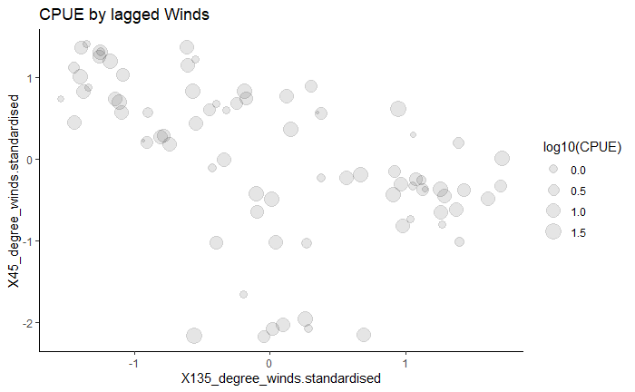

```r
whiting <- subset(my.df, Species == "Whiting")

#m1 <- lmer(CPUE.standardised ~ X135_degree_winds.standardised * X45_degree_winds.standardised +
#           Estuary_Type + Drought_Months + (1|Estuary), data = bream)
#AIC(m1) #215.42

p3 <- ggplot(whiting, aes(x = X135_degree_winds.standardised,y = X45_degree_winds.standardised, size = log10(CPUE))) + geom_point(alpha = 0.1) +
  theme_classic() + labs(title = "CPUE by lagged Winds")
p3
```

Model

```r
m3 <- glmmTMB(Catch ~ poly(X135_degree_winds.standardised, degree = 2) +
       poly(X45_degree_winds.standardised, degree = 2) +
       X135_degree_winds.standardised:X45_degree_winds.standardised+
        Estuary_Type *Drought_Months + (1|Estuary) , family = Gamma(link="log"),
       data = whiting, offset = log10(Effort_days))
performance::r2(m3) # 0.127
```

```
# R2 for Mixed Models

  Conditional R2: 0.679
     Marginal R2: 0.238
```

```r
AIC(m3) # 64.26
```

```
[1] 1383.275
```

Check assumptions

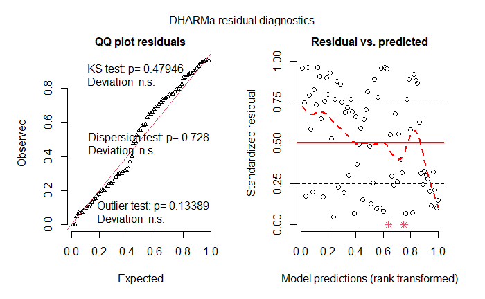

```r
simulationOutput <- simulateResiduals(fittedModel = m3, n = 250)
plot(simulationOutput, quantreg = F)
```

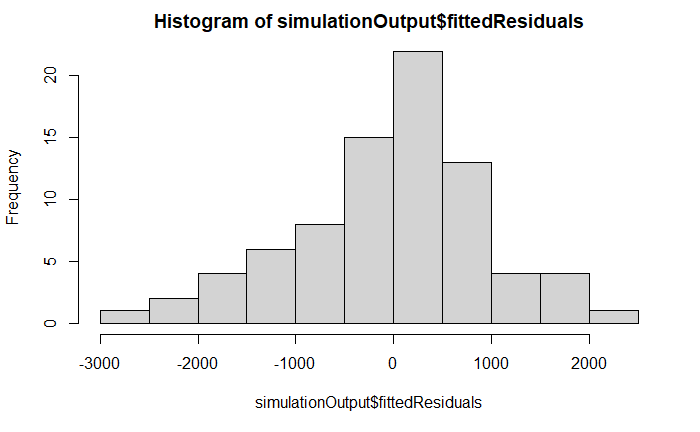

```r
# histograms
hist(simulationOutput$fittedResiduals)
```

```r
png("../plots/Model checks/Whiting model 1.png", width = 21, height = 14.8, units = "cm", res = 600)
plot(simulationOutput, quantreg = F)
dev.off()
```

```r
png("../plots/Model checks/Whiting model 2.png", width = 21, height = 14.8, units = "cm", res = 600)
```

```r
hist(residuals(m3))
dev.off()
```

Check significance

```r
car::Anova(m3)
```

```
Analysis of Deviance Table (Type II Wald chisquare tests)

Response: Catch
                                                               Chisq Df Pr(>Chisq)
poly(X135_degree_winds.standardised, degree = 2)              1.1796  2  0.5544488
poly(X45_degree_winds.standardised, degree = 2)               4.7493  2  0.0930469 .
Estuary_Type                                                  2.7106  2  0.2578726
Drought_Months                                               11.9589  1  0.0005439 ***
X135_degree_winds.standardised:X45_degree_winds.standardised  0.4035  1  0.5253106
Estuary_Type:Drought_Months                                   2.5122  2  0.2847565
---
Signif. codes:  0 ‘***’ 0.001 ‘**’ 0.01 ‘*’ 0.05 ‘.’ 0.1 ‘ ’ 1
```

```r
summary(m3)
```

```
 Family: Gamma  ( log )
Formula:          Catch ~ poly(X135_degree_winds.standardised, degree = 2) + poly(X45_degree_winds.standardised,
    degree = 2) + X135_degree_winds.standardised:X45_degree_winds.standardised +      Estuary_Type * Drought_Months + (1 | Estuary)
Data: whiting
 Offset: log10(Effort_days)

     AIC      BIC   logLik deviance df.resid
  1383.3   1414.2   -678.6   1357.3       67

Random effects:

Conditional model:
 Groups  Name        Variance Std.Dev.
 Estuary (Intercept) 0.2429   0.4928
Number of obs: 80, groups:  Estuary, 8

Dispersion estimate for Gamma family (sigma^2): 0.177

Conditional model:
                                                              Estimate Std. Error z value Pr(>|z|)
(Intercept)                                                   5.107725   0.315098  16.210  < 2e-16 ***
poly(X135_degree_winds.standardised, degree = 2)1            -0.463692   0.613043  -0.756  0.44942
poly(X135_degree_winds.standardised, degree = 2)2             0.597613   0.662266   0.902  0.36686
poly(X45_degree_winds.standardised, degree = 2)1             -0.876756   0.573849  -1.528  0.12655
poly(X45_degree_winds.standardised, degree = 2)2              0.616446   0.608703   1.013  0.31119
Estuary_TypeBarrier River                                     0.113360   0.430861   0.263  0.79247
Estuary_TypeDrowned River Valley                             -0.717492   0.482343  -1.488  0.13688
Drought_Months                                                0.076344   0.027089   2.818  0.00483 **
X135_degree_winds.standardised:X45_degree_winds.standardised -0.080552   0.126818  -0.635  0.52531
Estuary_TypeBarrier River:Drought_Months                     -0.041149   0.032362  -1.272  0.20354
Estuary_TypeDrowned River Valley:Drought_Months               0.008441   0.038336   0.220  0.82572
---
Signif. codes:  0 ‘***’ 0.001 ‘**’ 0.01 ‘*’ 0.05 ‘.’ 0.1 ‘ ’ 1
```

```r
whiting_Summary <- broom.mixed::tidy(m3)
whiting_Summary
```

| effect | component | group | term | estimate | std.error | statistic | p.value |
| --- | --- | --- | --- | --- | --- | --- | --- |
| fixed | cond | NA | (Intercept) | 5.107724664 | 0.31509775 | 16.2099687 | 4.287872e-59 |
| fixed | cond | NA | poly(X135_degree_winds.standardised, degree = 2)1 | -0.463692296 | 0.61304330 | -0.7563777 | 4.494228e-01 |
| fixed | cond | NA | poly(X135_degree_winds.standardised, degree = 2)2 | 0.597612925 | 0.66226628 | 0.9023756 | 3.668574e-01 |
| fixed | cond | NA | poly(X45_degree_winds.standardised, degree = 2)1 | -0.876755637 | 0.57384851 | -1.5278521 | 1.265493e-01 |
| fixed | cond | NA | poly(X45_degree_winds.standardised, degree = 2)2 | 0.616445897 | 0.60870290 | 1.0127205 | 3.111937e-01 |
| fixed | cond | NA | Estuary_TypeBarrier River | 0.113360206 | 0.43086087 | 0.2631017 | 7.924722e-01 |
| fixed | cond | NA | Estuary_TypeDrowned River Valley | -0.717491763 | 0.48234335 | -1.4875125 | 1.368795e-01 |
| fixed | cond | NA | Drought_Months | 0.076343801 | 0.02708915 | 2.8182430 | 4.828725e-03 |
| fixed | cond | NA | X135_degree_winds.standardised:X45_degree_winds.standardised | -0.080552278 | 0.12681789 | -0.6351807 | 5.253106e-01 |
| fixed | cond | NA | Estuary_TypeBarrier River:Drought_Months | -0.041149116 | 0.03236161 | -1.2715412 | 2.035362e-01 |

[output cut: 2 more lines]

```r
write.csv(whiting_Summary, "../Data/Whiting Summary Table.csv", row.names = F)
```

Therefore wind is not important for whiting?

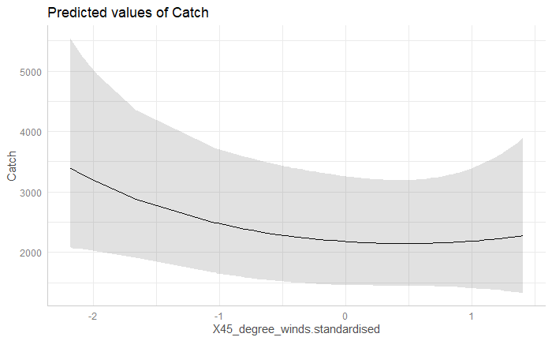

```r
plot(ggeffect(m3, terms = "X45_degree_winds.standardised [all]"))
```

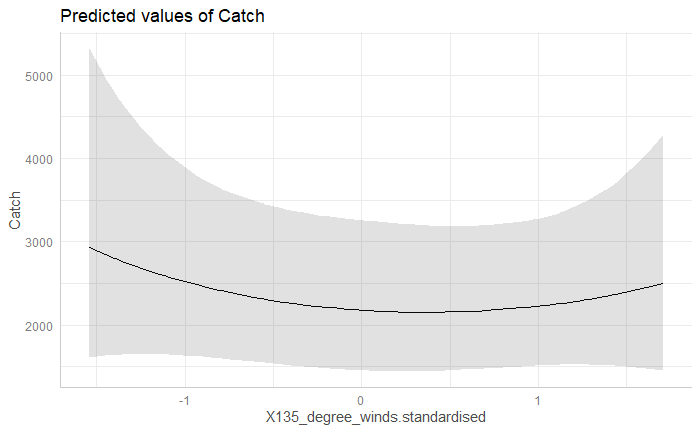

```r
plot(ggeffect(m3, terms = "X135_degree_winds.standardised [all]"))
```

```r
#plot(ggeffect(m3, terms = "Estuary_Type:Drought_Months"))
```

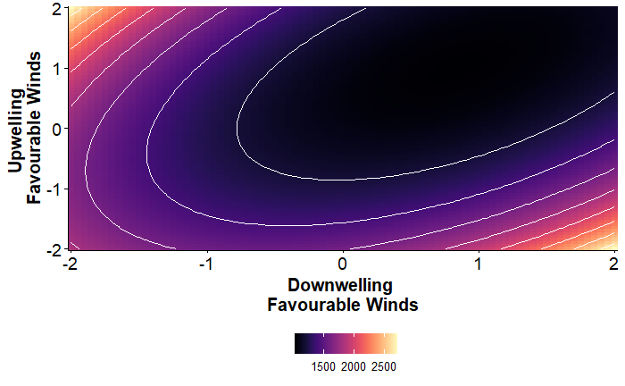

```r
nums <- seq(-2,2, by = 0.05)
heat_dataWhiting <- data.frame("X135_degree_winds.standardised" = rep(0,81*81), # makes empty dataframe ready for values
                         "X45_degree_winds.standardised" =  rep(0,81*81),
                         "Catch" =  rep(0,81*81))
Nn <- 1
# loop for NE
for (i in 1:length(nums)){
  for (j in 1:length(nums)){
    pred_map <- data.frame("X45_degree_winds.standardised" = nums[i],
                           "X135_degree_winds.standardised" = nums[j],
                           "Drought_Months" = mean(my.df$Drought_Months),
                           "Estuary_Type" = "Drowned River Valley",
                           "Estuary" = "Hawkesbury River",
                           "Effort_days" = mean(my.df$Effort_days))
    PredX <- predict(m3, newdata = pred_map, type = "response", se.fit = F)
    heat_dataWhiting$Southeast.Winds[Nn] <- pred_map$X135_degree_winds.standardised[1]
    heat_dataWhiting$Northeast.Winds[Nn] <- pred_map$X45_degree_winds.standardised[1]
    heat_dataWhiting$Abundance[Nn] <- PredX#$fit
    #print(paste("This is line ", Nn, " out of 6561"))
    Nn <- Nn + 1
  }
}

pW <- ggplot(heat_dataWhiting, aes(x = Southeast.Winds,y = Northeast.Winds)) + geom_tile(aes(fill = Abundance)) +
  geom_contour(col="white", aes(z = Abundance)) +#, binwidth = 0.002
  scale_x_continuous(expand = c(0,0)) +
  scale_y_continuous(expand = c(0,0)) +
  #scale_fill_gradient(low = "blue", high = "red") +
  theme_classic() +
  viridis::scale_fill_viridis(option = "magma", name="Predicted Catch") + # or geom_raster()
  xlab("Downwelling \nFavourable Winds") + ylab("Upwelling \nFavourable Winds") +
  theme(axis.title.x = element_text(face="bold", colour="black", size = 15),
        axis.text.x  = element_text(colour="black", size = 14),
        axis.title.y = element_text(face="bold", colour="black", size = 15),
        axis.text.y  = element_text(colour="black", size = 14),
        axis.ticks = element_line(colour="black"),
        legend.title = element_blank(),
        legend.text = element_text(colour="black", size=10),
        legend.position = "bottom")

pW
```

```r
write.csv(heat_dataWhiting, "../Data/Whiting heamap prediction data.csv", row.names = F)
```

##Now Luderick## Prepare Data

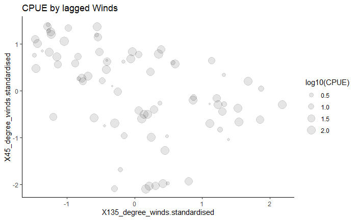

```r
luderick <- subset(my.df, Species == "Luderick")

#m1 <- lmer(CPUE.standardised ~ X135_degree_winds.standardised * X45_degree_winds.standardised +
#           Estuary_Type + Drought_Months + (1|Estuary), data = bream)
#AIC(m1) #215.42

p4 <- ggplot(luderick, aes(x = X135_degree_winds.standardised,y = X45_degree_winds.standardised, size = log10(CPUE))) + geom_point(alpha = 0.1) +
  theme_classic() + labs(title = "CPUE by lagged Winds")
p4
```

Model

```r
m4 <- glmmTMB(Catch ~ poly(X135_degree_winds.standardised, degree = 2) +
       poly(X45_degree_winds.standardised, degree = 2) +
       X135_degree_winds.standardised:X45_degree_winds.standardised+
        Estuary_Type *Drought_Months + (1|Estuary) , Gamma(link="log"),
       data = luderick, offset = log10(Effort_days))
performance::r2(m4) # 0.127
```

```
# R2 for Mixed Models

  Conditional R2: 0.928
     Marginal R2: 0.249
```